# Label Class Summaries

ROSSyndicate

2023-07-19

## Load the labels file into the environment

```r
labels_file <- list.files('data/labels/', full.names = T)
labels <- read_csv(labels_file)
```

## Display data per band and per mission by class

First, let’s arrange the classes in a way that makes sense.

```r
labels <- labels %>%
  mutate(class = factor(class,
         c('openWater', 'lightNearShoreSediment', 'darkNearShoreSediment',
           'offShoreSediment', 'algalBloom', 'other', 'cloud', 'shorelineContamination')))
```

Since the Landsat and Sentinel data are definitely different, let’s split those out first.

```r
landsat_labels = labels %>% filter(grepl('LS', mission, ignore.case = T))
sen_labels = labels %>% filter(grepl('sen', mission, ignore.case = T))
```

### Look at the Sentinel data first

Create a list of bands for Sen-2

```r
sen_bands = c(expr(Red), expr(Green), expr(Blue), expr(B5), expr(B6), expr(B7), expr(B8), expr(B11), expr(B12))
```

Create some helper functions. First to get count and add a label below the y = 0, then another to create a boxplot for each class per band.

```r
add_n <- function(x) {
  if (max(x) > 2) {
    return(c(y = -200, label = length(x)))
  } else {
  return(c(y = -0.05, label = length(x)))
  }
}

make_class_plot_sen = function(x) {
  ggplot(sen_labels, aes(x = class, y = {{ x }})) +
    geom_boxplot() +
    theme_bw() +
    theme(axis.text.x = element_text(angle = 45, hjust = 1)) +
    stat_summary(fun.data = add_n, geom = 'text', fun.y = median)
}
```

And map those through the sentinel band names

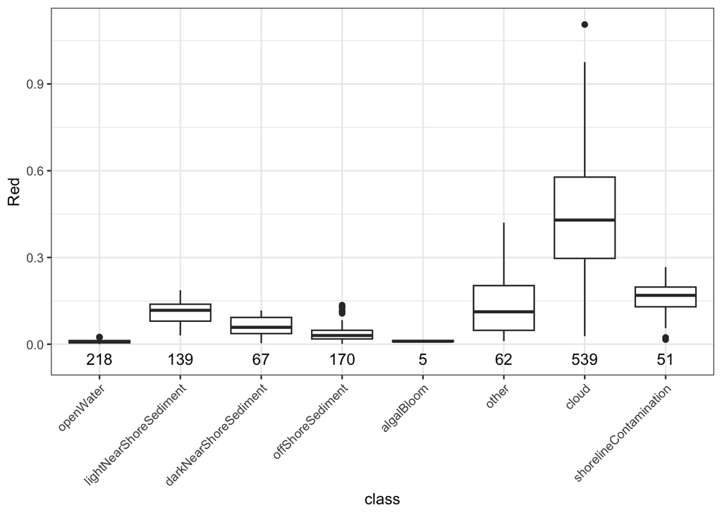

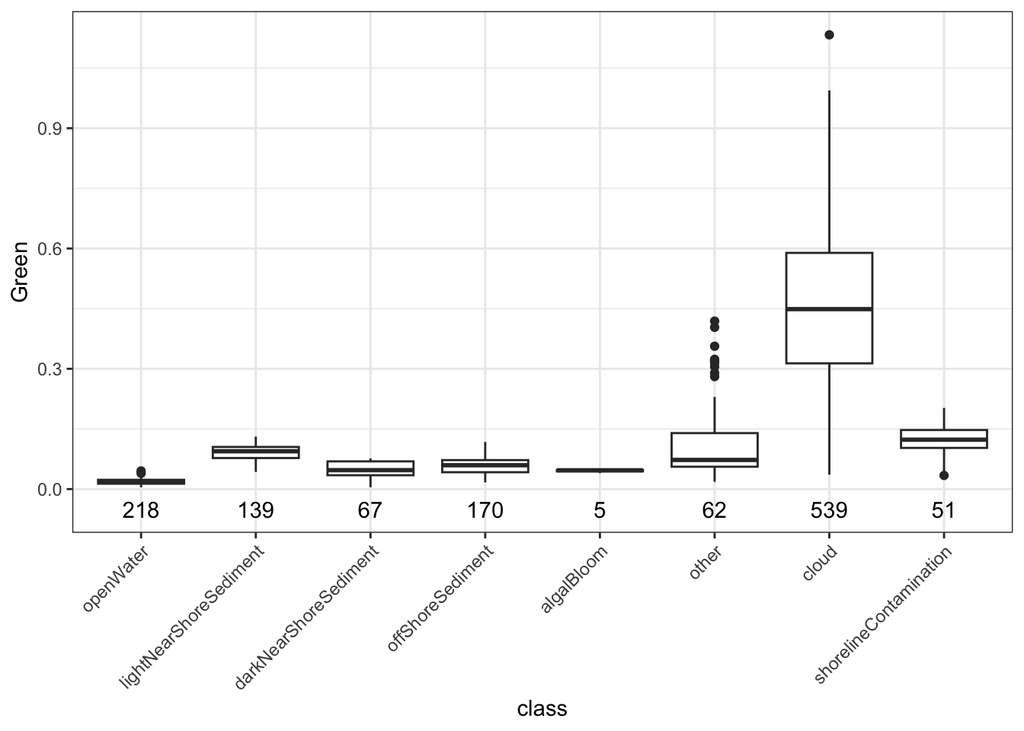

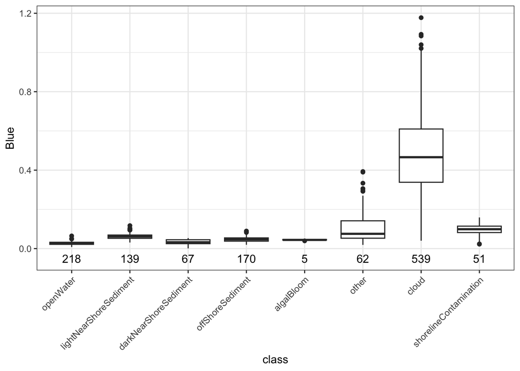

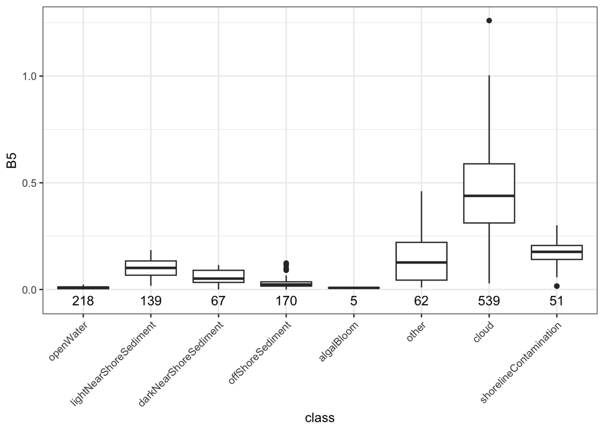

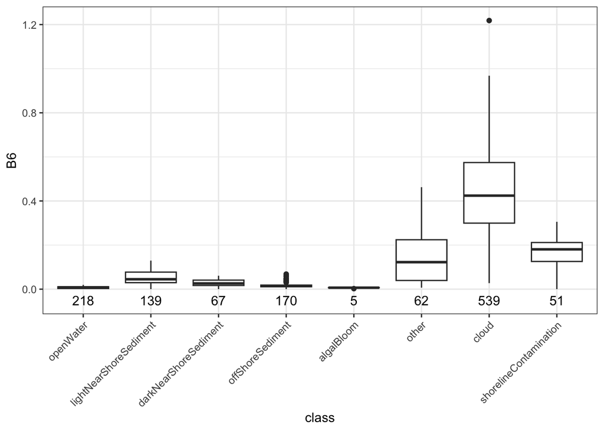

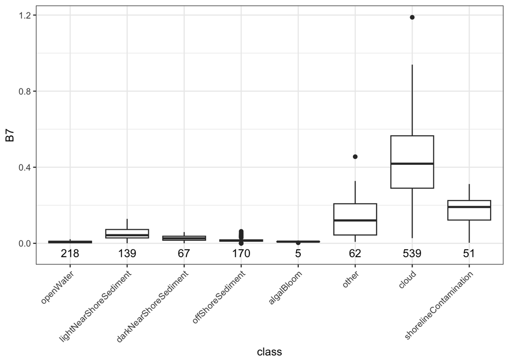

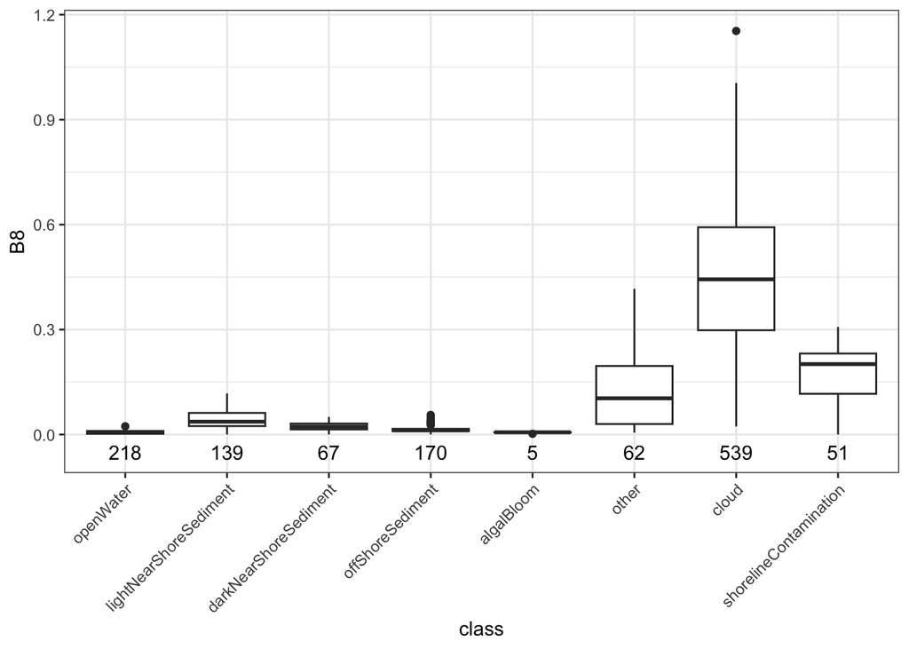

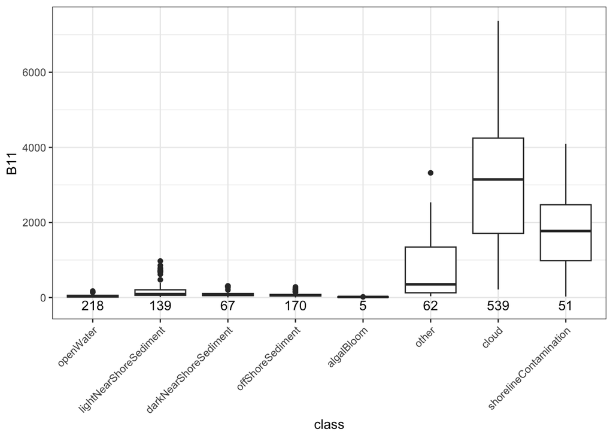

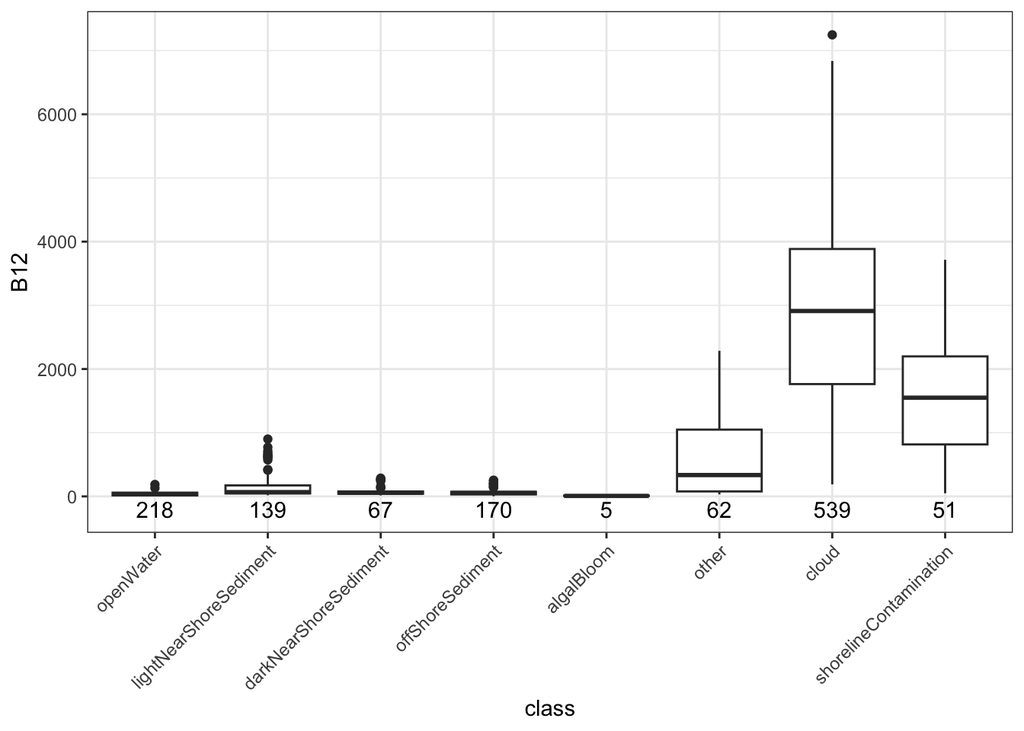

```r
map(sen_bands, make_class_plot_sen)
```

Since the cloud, shoreline contamination and other classes seem to be rather different, let’s drop those to see the differences for the sediment label classes

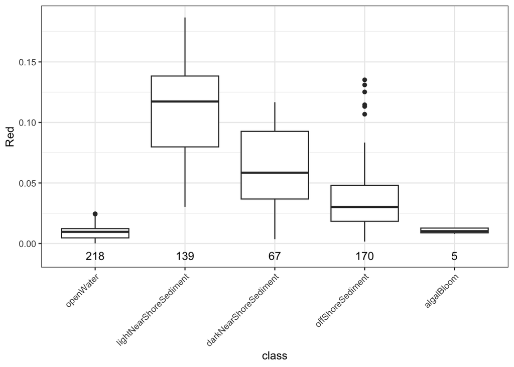

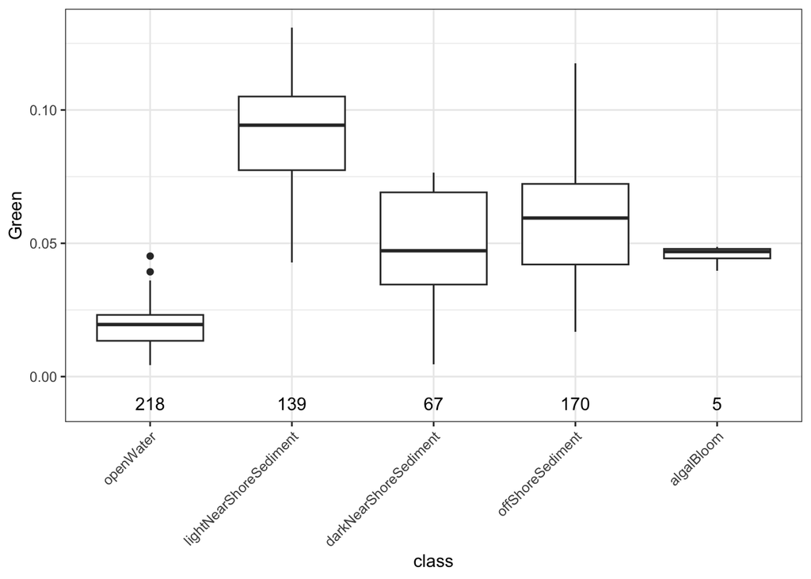

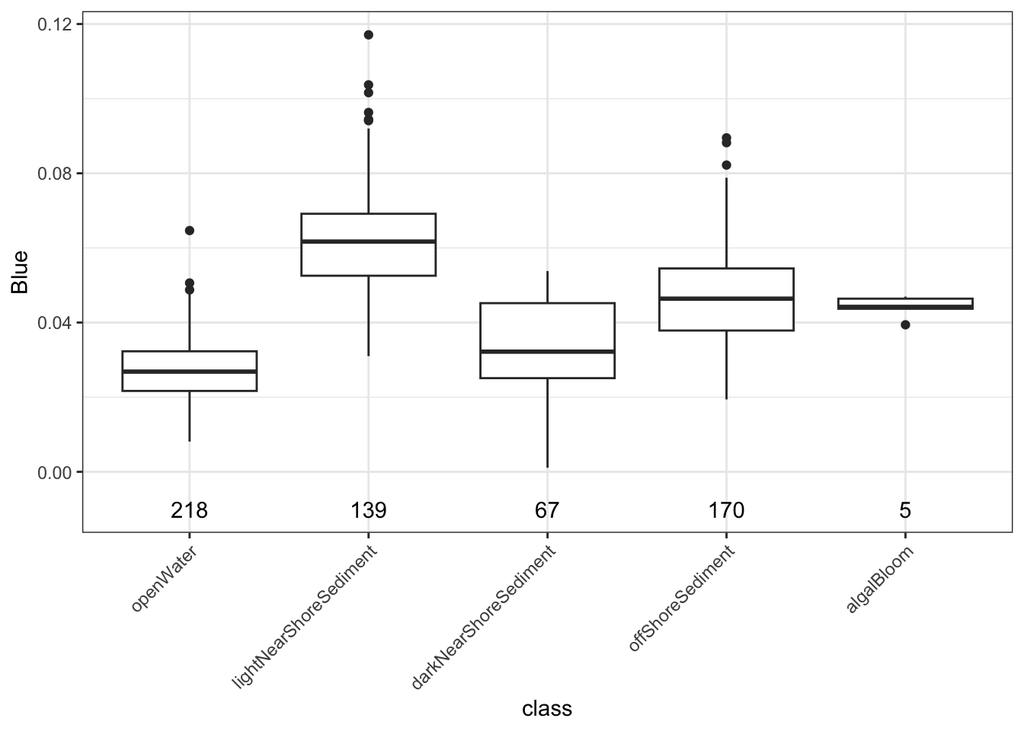

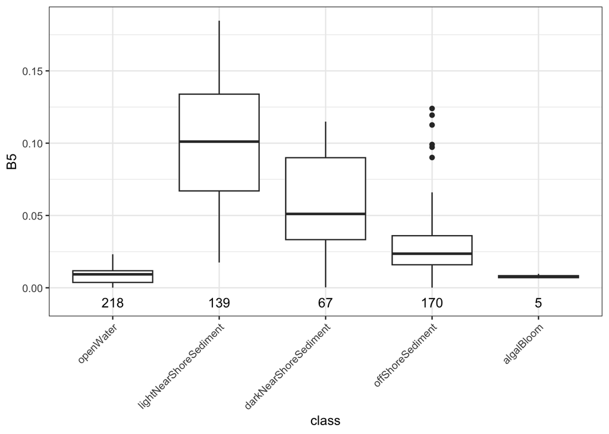

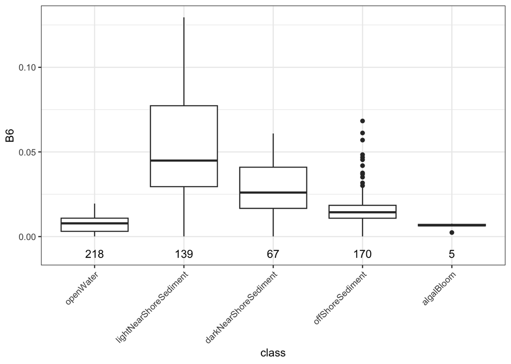

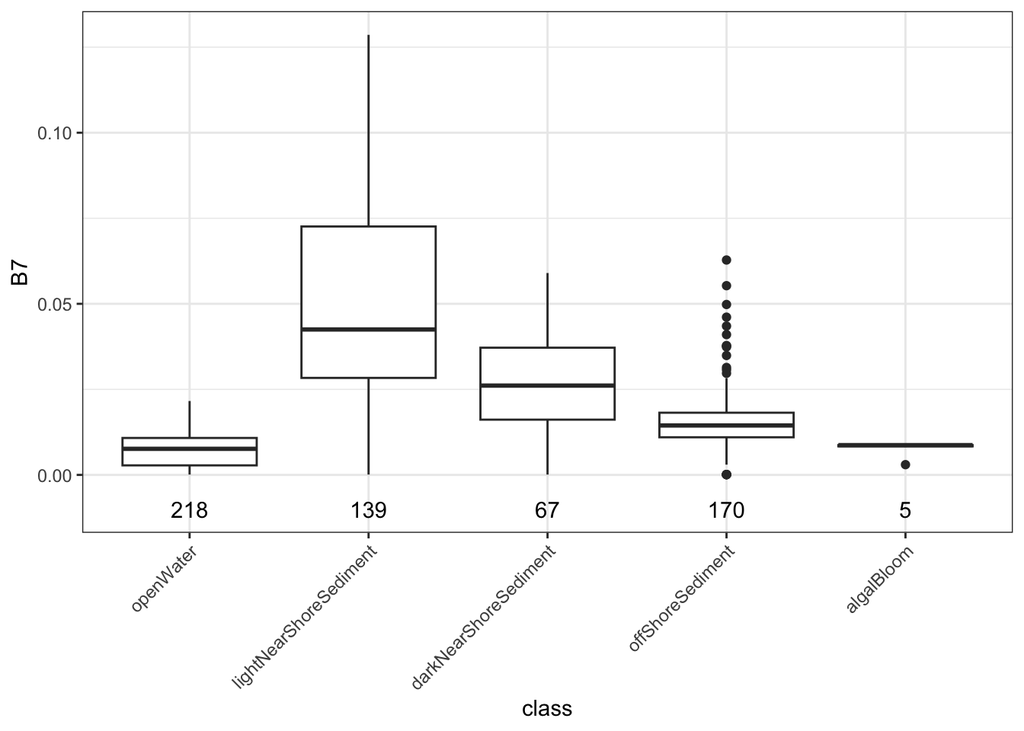

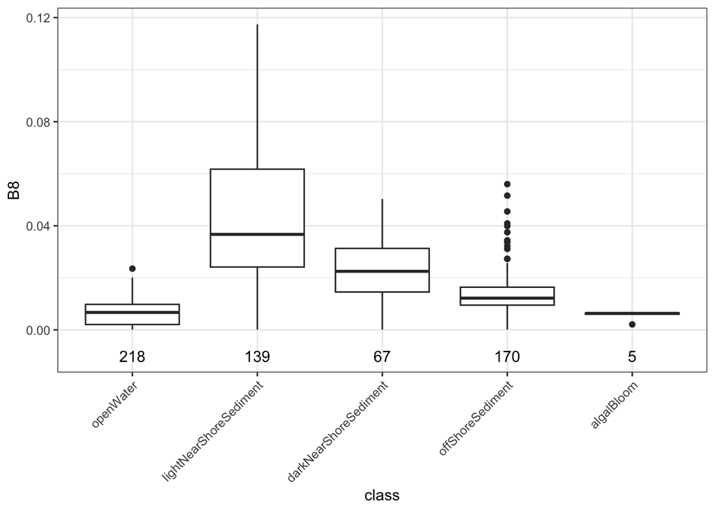

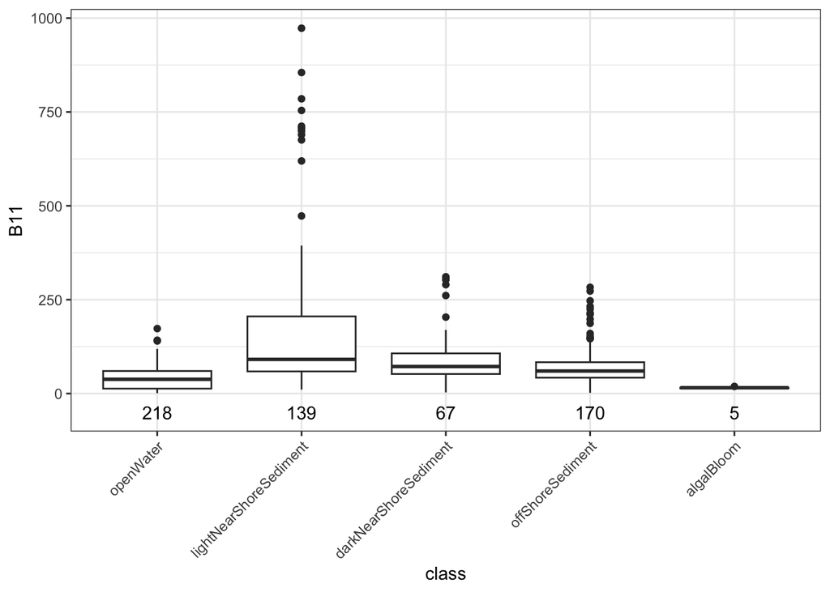

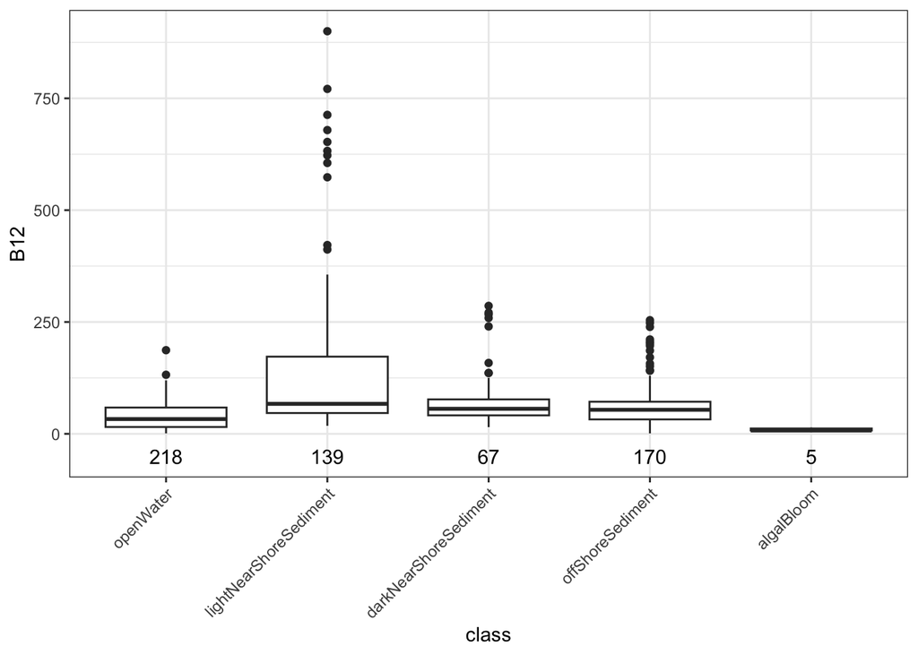

```r
sen_labels_select <- sen_labels %>%
  filter(!class %in% c('cloud', 'shorelineContamination', 'other'))

add_n_select <- function(x) {
  if (max(x) > 2) {
    return(c(y = -50, label = length(x)))
  } else {
  return(c(y = -0.01, label = length(x)))
  }
}

make_class_plot_sen_sel = function(x) {
  ggplot(sen_labels_select, aes(x = class, y = {{ x }})) +
    geom_boxplot() +
    theme_bw() +
    theme(axis.text.x = element_text(angle = 45, hjust = 1)) +
    stat_summary(fun.data = add_n_select, geom = 'text', fun.y = median)
}

map(sen_bands, make_class_plot_sen_sel)
```

### And now for Landsat

Create a list of bands for Landsat

```r
ls_bands = c(expr(Red), expr(Green), expr(Blue), expr(B5), expr(B6), expr(B7))
```

```r
make_class_plot_ls = function(x) {
  landsat_labels %>%
    group_by(mission) %>%
    ggplot(., aes(x = class, y = {{ x }}, color = mission)) +
    geom_boxplot() +
    theme_bw() +
    theme(axis.text.x = element_text(angle = 45, hjust = 1)) +
    scale_color_viridis_d()
}
```

And map those through the Landsat band names

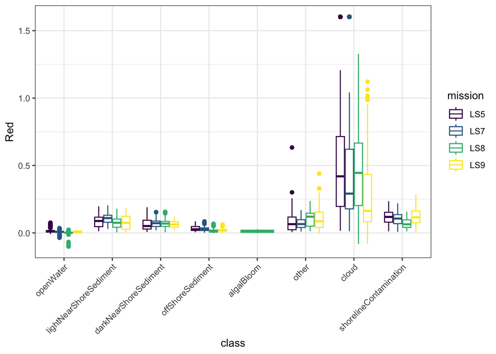

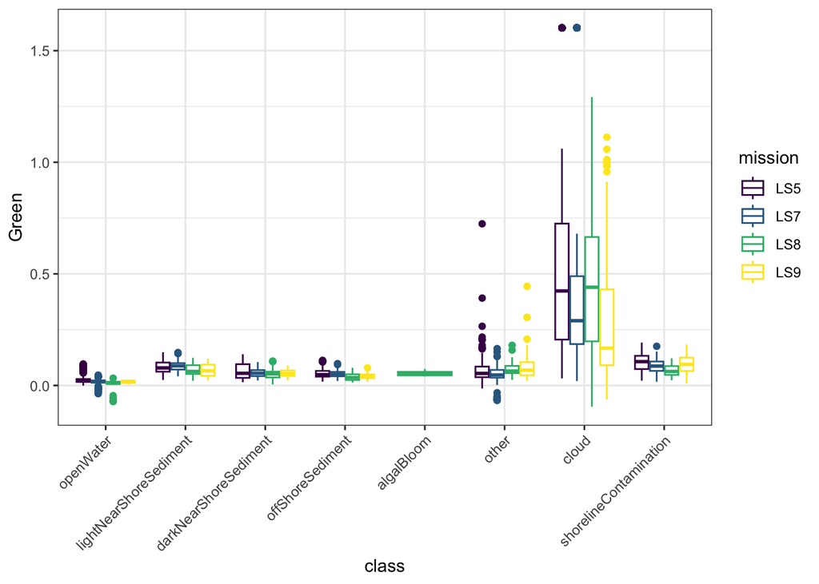

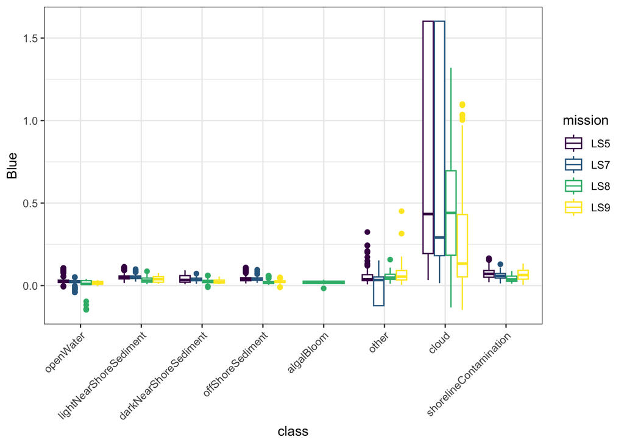

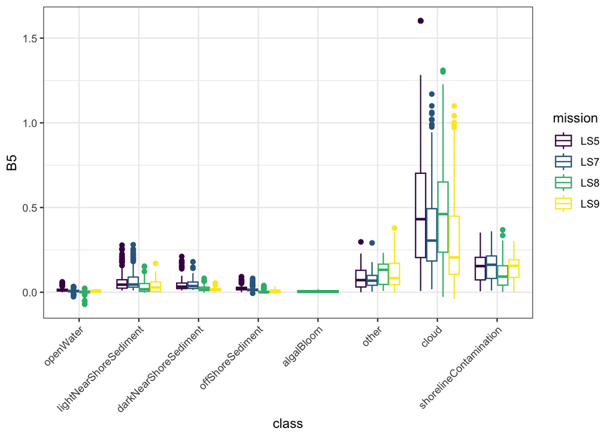

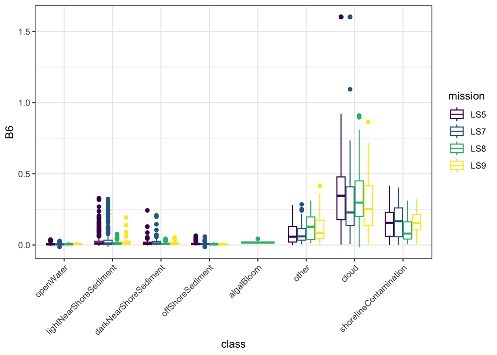

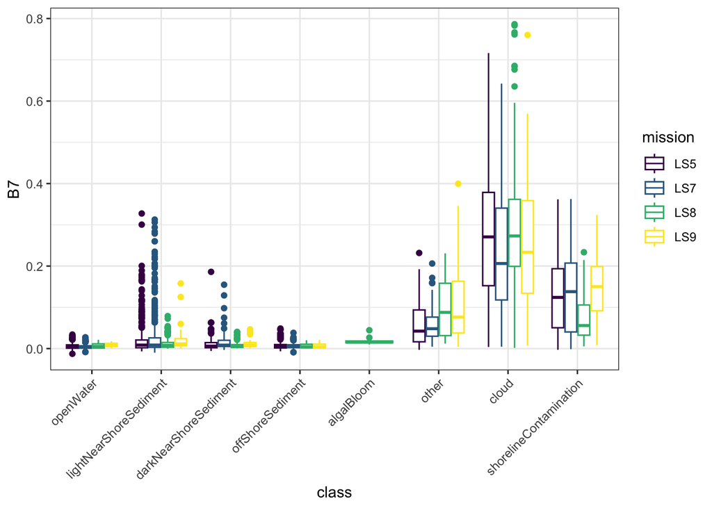

```r
map(ls_bands, make_class_plot_ls)
```

These also have more range for those three classes, let’s limit to the classes we are especially interested in.

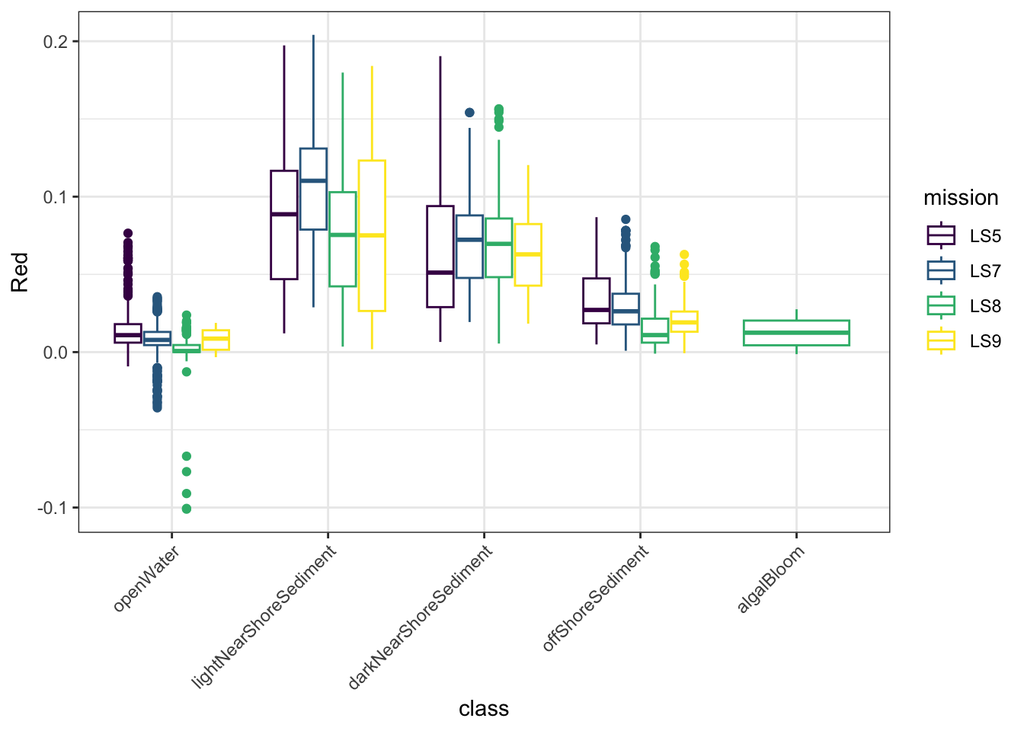

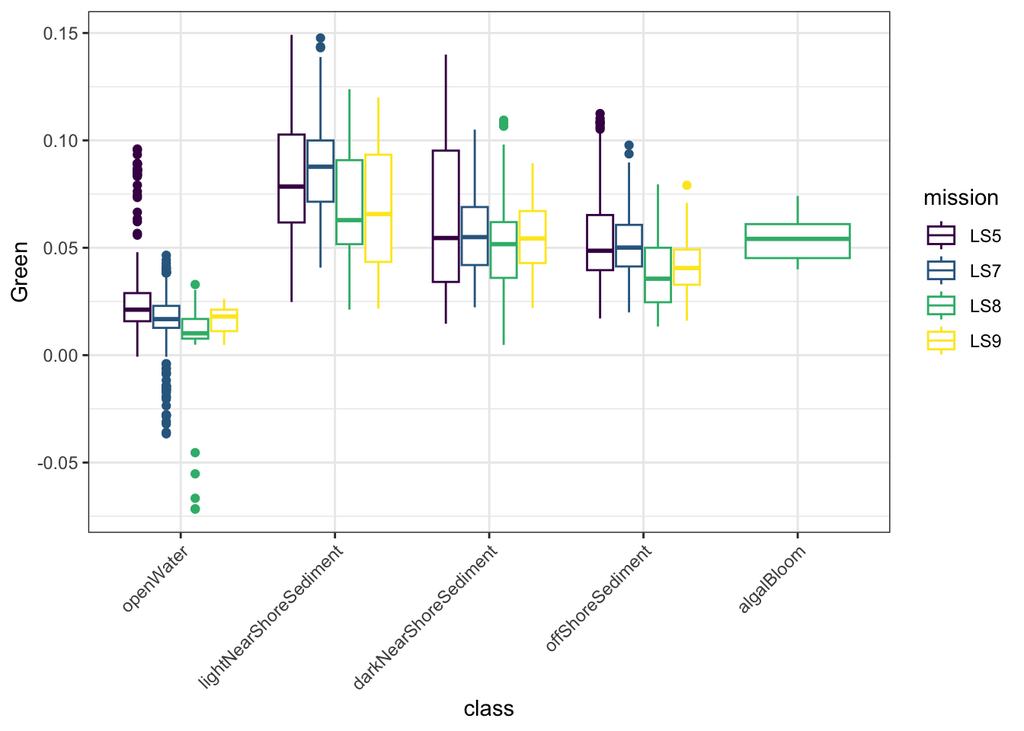

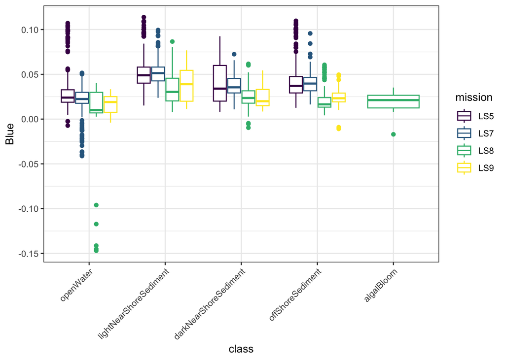

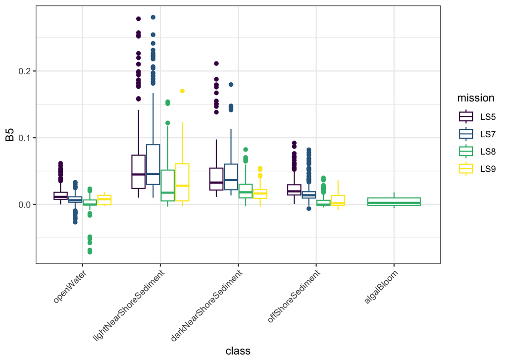

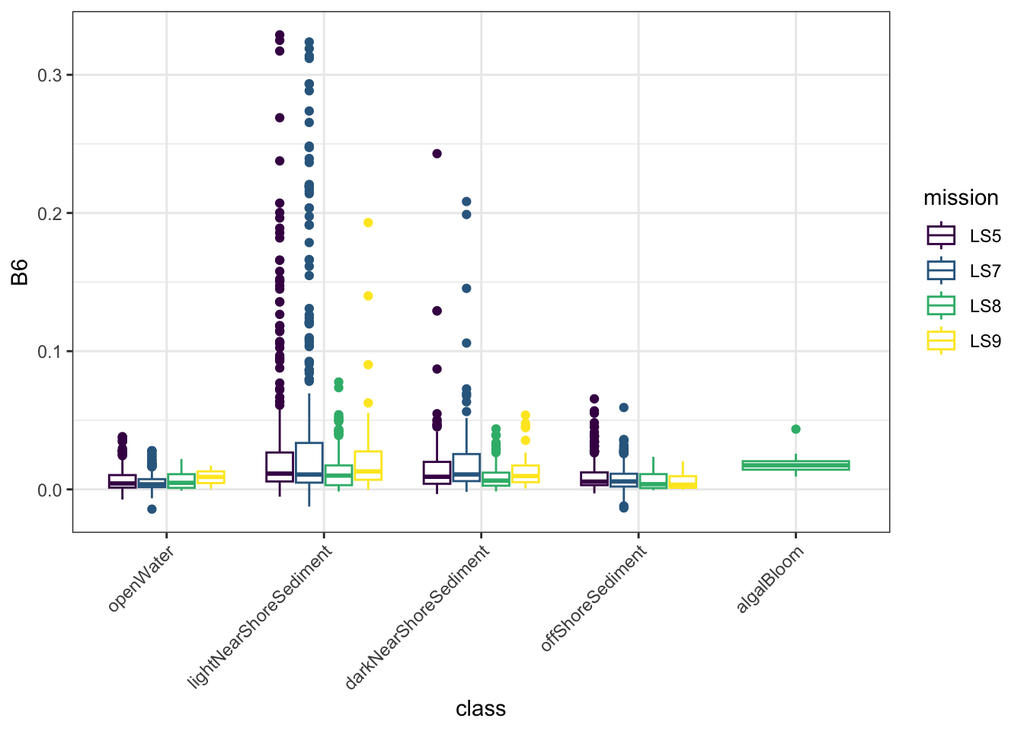

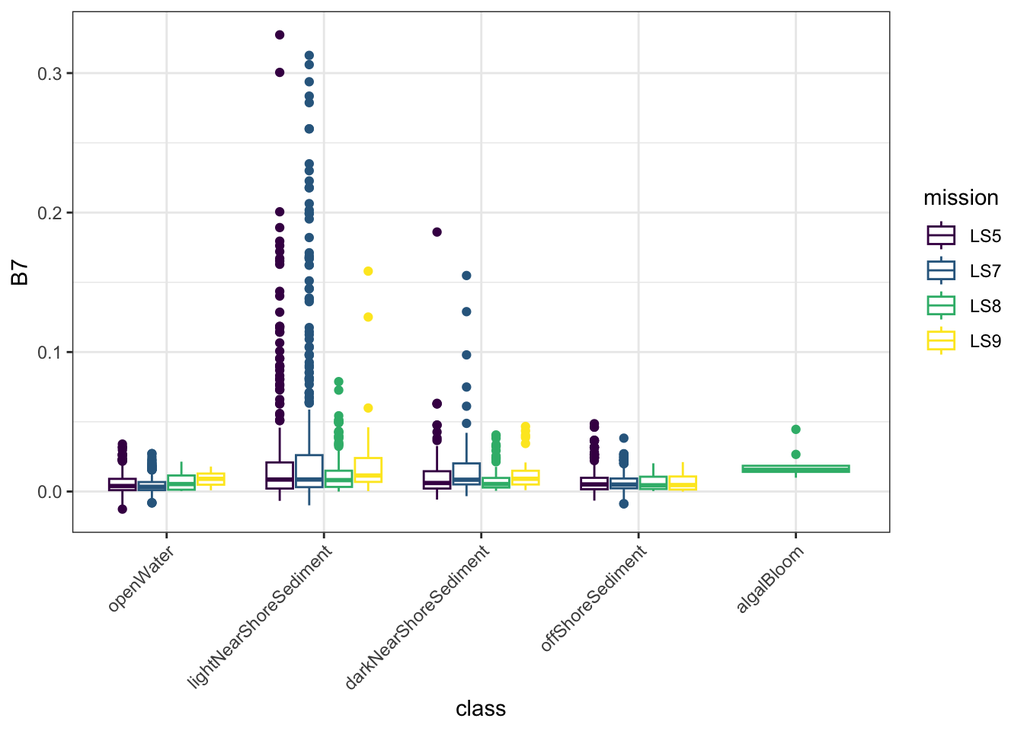

```r
landsat_labels_select = landsat_labels %>%
  filter(!class %in% c('cloud', 'shorelineContamination', 'other'))

make_class_plot_ls_sel = function(x) {
  landsat_labels_select %>%
    group_by(mission) %>%
    ggplot(., aes(x = class, y = {{ x }}, color = mission)) +
    geom_boxplot() +
    theme_bw() +
    theme(axis.text.x = element_text(angle = 45, hjust = 1)) +
    scale_color_viridis_d()
}

map(ls_bands, make_class_plot_ls_sel)
```

In an ideal world, I think we should create models for each Landsat mission. There are some slight range differences between each of the missions that may introduce confusion by aggregating 5/7 and 8/9.